# Covid19 Situation in Outaouais Schools

The Quebec government maintains a [list of all schools that have had one or more confirmed, active covid-19 cases](https://www.quebec.ca/sante/problemes-de-sante/a-z/coronavirus-2019/liste-des-cas-de-covid-19-dans-les-ecoles/) in the previous 14 days. The figures on this page show these listings over time. Each dot represents a calendar day and is color-coded according to additional information provided in the list. Also see further notes at the bottom of this page.

# Schools with confirmed cases

## CSS des Draveurs

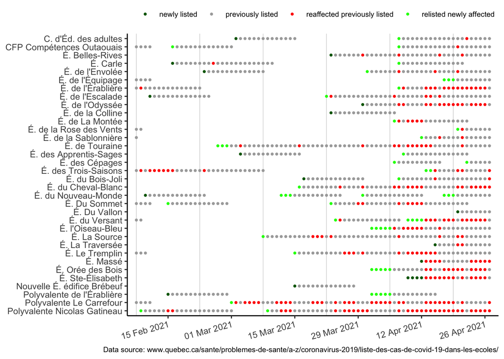

## CSS des Portages-de-l’Outaouais

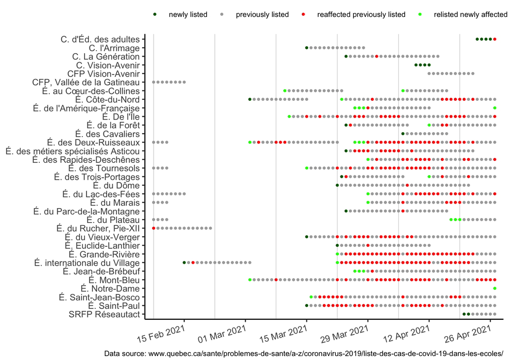

## Western Québec School Board

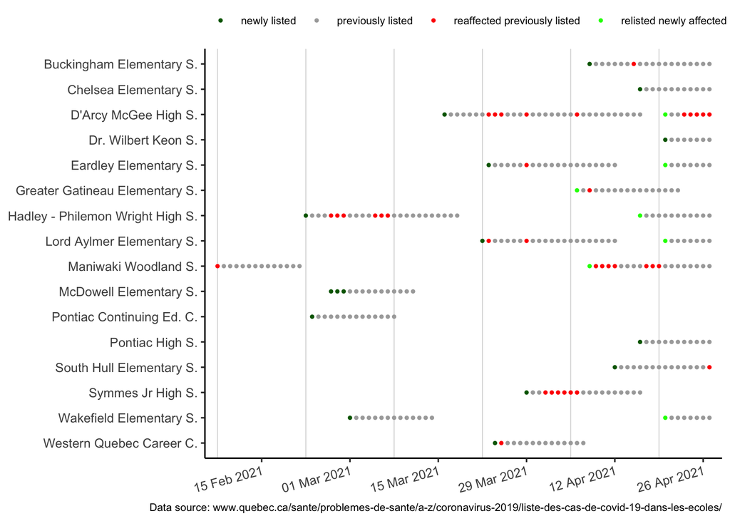

## CSS au Cœur-des-Vallées

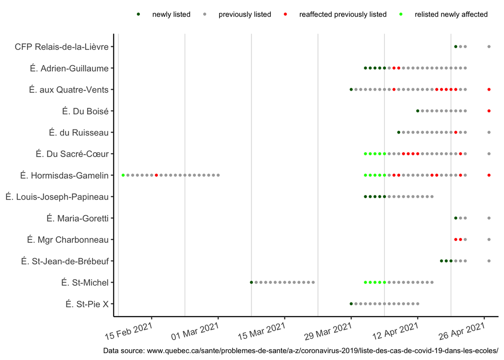

## CSS des Hauts-Bois-de-l’Outaouais

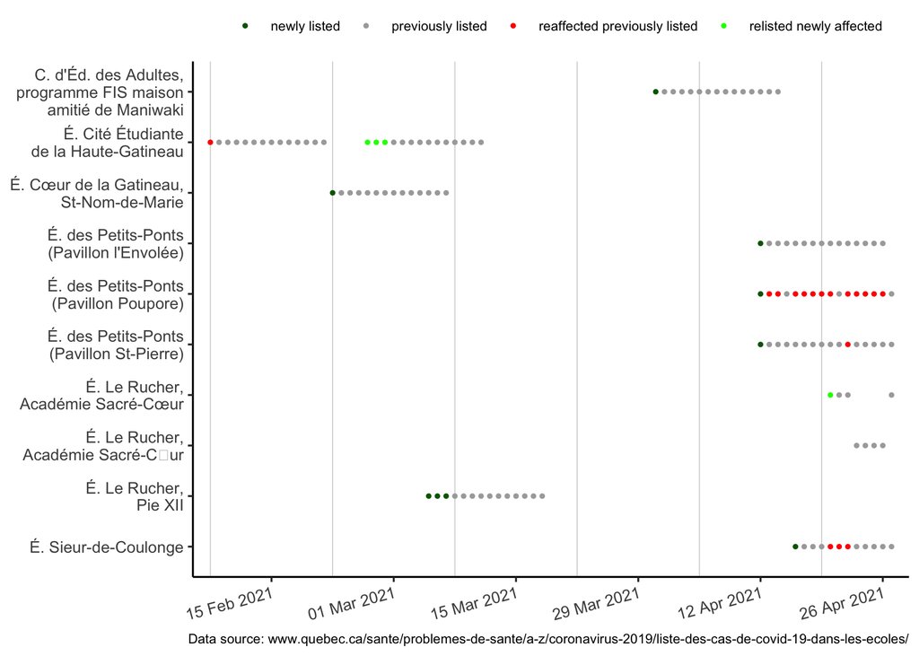

## École privée

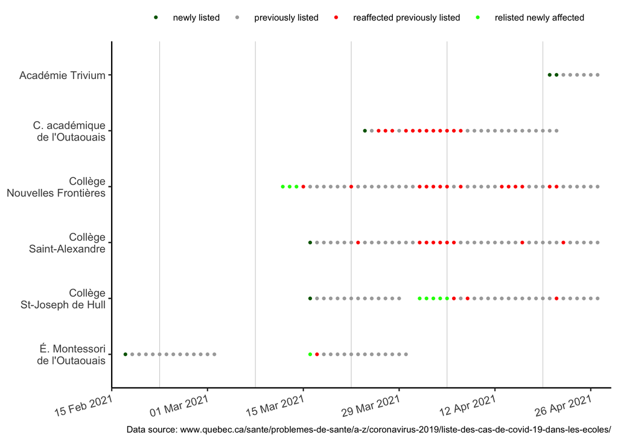

# Information on this site

## Explanatory notes

The list of schools is downloaded daily, processed and combined into a dataset. For the lists published before I began the daily downloads, I accessed the [CCODWG Covid19 Canada Archive](http://data.opencovid.ca/archive/index.html), which goes back to Feb 8, 2021. (The list has been available in PDF format since the beginning of the school year, also present in the archive. Processing these takes quite a bit more work; I may include this at a later time.) Further information about this project is provided on the main page.

In the figures, the following are abbreviated: École (É.); School (S.); Education (Ed.); Centre (C.); Centre de formation professionnelle (CFP); and Service régional de la formation professionnelle et du service aux entreprises Réseautact (SRFP Réseautact).

Updates of this page usually occur after 12pm. If the figures do not show the latest data, reload this page in your web browser.

Last data update: 2021-04-27 12:43:50

Last page update: 2021-04-27 13:50:10

## Disclaimer

Please read this disclaimer (“disclaimer”) carefully before using this website (the “Site”). All information provided on the Site is merely for general informational and educational purposes. It does not contain, and is not a substitute for, professional advice.

Under no circumstance shall I have any liability to you for any loss or damage of any kind incurred as a result of the use of the site or reliance on any information provided on the site. Your use of the site and your reliance on any information on the site is solely at your own risk.

While the information on the Site has been verified to the best of my abilities, I cannot guarantee that there are no mistakes or errors. All information on the Site is provided in good faith, however I make no representation or warranty of any kind, express or implied, regarding the accuracy, adequacy, validity, reliability, availability or completeness of any information on the Site.

I reserve the right to change this policy at any given time, in which case this disclaimer will be updated.

This page is maintained by [Timo Thoms](https://twitter.com/TimoThoms). Questions, concerns, and suggestions can be raised through [GitHub Discussions](https://github.com/timothoms/covid19Outaouais/discussions).